# WCSS 2019: Exploring Twitter Trolls

2/5/2019

## Introduction to 2016 Russian Twitter Troll Dataset

## According to the US Office of the Director of National Intelligence:s

- Russian President Vladimir Putin ordered an influence campaign in 2016 aimed at the US presidential election. Russia’s goals were to undermine public faith in the US democratic process, denigrate Secretary Clinton, and harm her electability and potential presidency.
- Moscow's influence campaign followed a Russian messaging strategy that blends covert intelligence operations—such as cyber activity—with overt efforts by Russian Government agencies, state-funded media, third-party intermediaries, and paid social media users or "trolls."
- The House Intelligence released a list of 2,752 false Twitter accounts believed to be operated by a known Russian troll factory – the Internet Research Agency.

## Recovered Twitter Data

- The trolls were removed from Twitter once they were identified.
- NBC News was able to recover the tweets posted by the trolls and made the data public.
- NBC collaborated with Neo4j to conduct network analysis and answer the question - how did these trolls succeed?

## Troll Personas

**Three types of Profiles:**

- The Typical American Citizen
- The Local Media Outlet
- The Local Political Party

**Three main sentiments:**

- Focus on Right Wing Politics (Positive)
- Focus on Left Wing Politics (Negative)
- Focus on Black Lives Matter (Positive)

## Internal Workings

- There were only a handful of trolls that created their own content
- A majority of the trolls simply retweeted others in order to amplify their message

## Reproduce these results in R & igraph

## How to make a graph: Edge List

| user_key | retweeted | text |
| --- | --- | --- |
| cookncooks | ltapoll | RT @ltapoll: Who was/is the best president of the past 25 years? (Vote & Retweet) |
| queenofthewo | jww372 | RT @jww372: I don't have to guess your religion! #ChristmasAftermath |
| mrclydepratt | shareblue | RT @Shareblue: Pence and his lawyers decided which of his official emails the public could seehttps://t.co/HjhPguBK1Y by @alisonrose711 |
| baobaeham | mdblanchfield | RT @MDBlanchfield: You’ll never guess who tweeted something false that he saw on TV - The Washington Post https://t.co/K2e4XdXRfu |
| judelambertusa | 100percfedup | RT @100PercFEDUP: New post: WATCH: DIAMOND AND SILK Rip On John Kerry Over Israel Comments (VIDEO) https://t.co/NkdKaQ9yYu |
| ameliebaldwin | ariawilsongop | RT @AriaWilsonGOP: 3 Women Face Charges After Being Caught Stealing Dozens Of Trump Signs https://t.co/JjlZxaW3JN https://t.co/qW2Ok9ROxH |

## How to make a graph: Aggregation

| user_key | retweeted | n |
| --- | --- | --- |
| paulinett | blicqer | 1049 |
| melanymelanin | blicqer | 798 |
| paulinett | zaibatsunews | 222 |
| giselleevns | chrixmorgan | 218 |
| brianaregland | feministajones | 200 |
| hyddrox | cmdorsey | 178 |

## Visualize the Graph

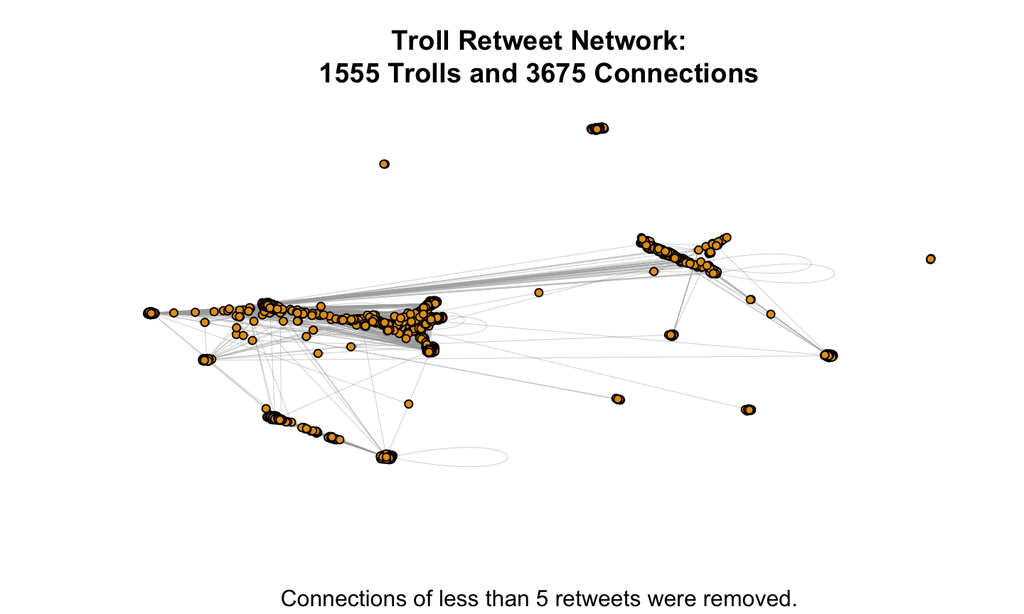

## Calculate (Directed) PageRank

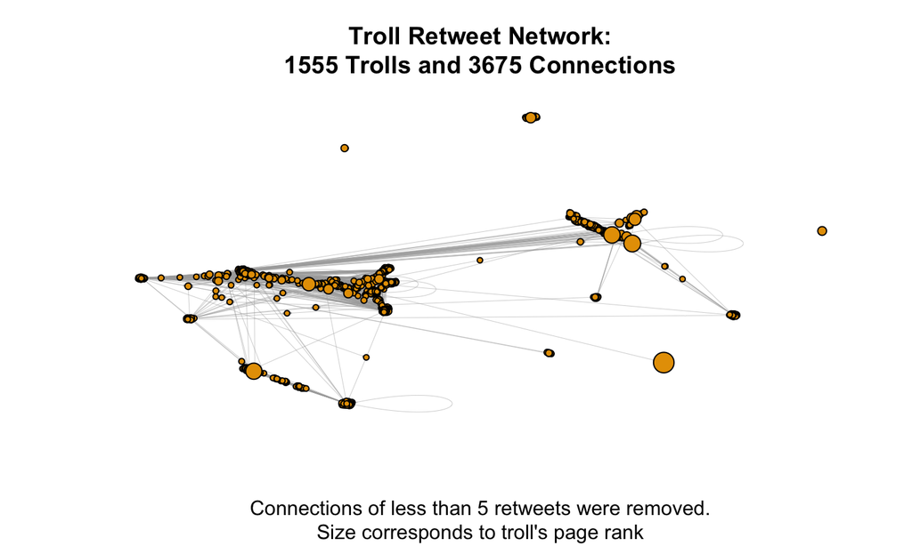

## Analyze Top PageRanked Trolls

| name | PageRank | InStrength | OutStrength | OriginalTweets | AllTweets |
| --- | --- | --- | --- | --- | --- |
| rt_com | 0.0050983 | 83 | 0 | NA | NA |
| blacktolive | 0.0039910 | 29 | 8 | 203 | 236 |
| gloed_up | 0.0038694 | 92 | 45 | 181 | 285 |
| chiefplan1 | 0.0038029 | 240 | 0 | NA | NA |
| rt_america | 0.0035941 | 49 | 0 | NA | NA |
| ten_gop | 0.0029589 | 371 | 57 | 3084 | 3170 |
| joyannreid | 0.0025983 | 189 | 0 | NA | NA |
| owillis | 0.0021334 | 42 | 0 | NA | NA |
| spiegelonline | 0.0020765 | 125 | 0 | NA | NA |
| blicqer | 0.0018729 | 2110 | 0 | NA | NA |

## Trolls Retweeted Non-Trolls

Some twitter handles were not counted in the data because they were not among the list of twitter trolls.

- **rt_com** and **rt_america** are part of the RT Network. A moscow based television network that used to be called "Russia Today"
- **chiefplan1**, **joyannreid**, **owillis** are left-wing news personalities.
- **spiegelonline** is a german news website

## Remove Non-Trolls and Recalculate

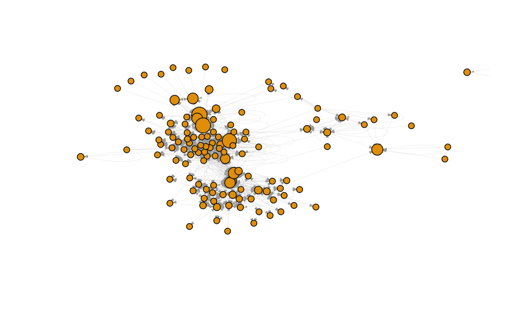

## Analyze Cleaned Network

| name | PageRank | InStrength | OutStrength | RetweetedTrolls | OriginalTweets |
| --- | --- | --- | --- | --- | --- |
| ten_gop | 0.0894196 | 436 | 46 | 46 | 3084 |
| pamela_moore13 | 0.0859803 | 95 | 7 | 7 | 1310 |
| politweecs | 0.0782048 | 56 | 1 | 1 | 439 |
| danageezus | 0.0508612 | 366 | 5 | 5 | 302 |
| blacktolive | 0.0503435 | 36 | 8 | 8 | 203 |
| tpartynews | 0.0468042 | 113 | 197 | 197 | 1615 |
| realten_gop | 0.0460308 | 14 | 82 | 82 | 91 |
| chrixmorgan | 0.0442347 | 385 | 7 | 7 | 320 |
| giselleevns | 0.0408958 | 246 | 657 | 657 | 1166 |
| thefoundingson | 0.0357036 | 185 | 146 | 146 | 3416 |

## Community Detection (Walktrap)

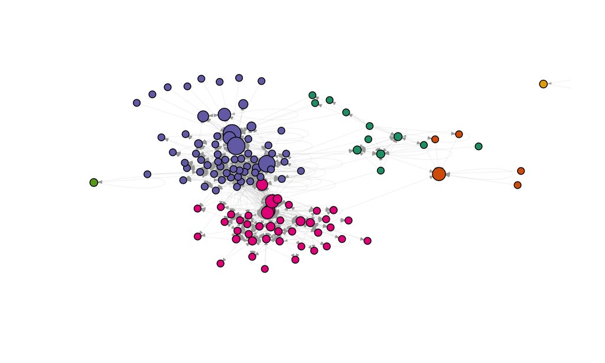

## What Hashtags do these groups use?

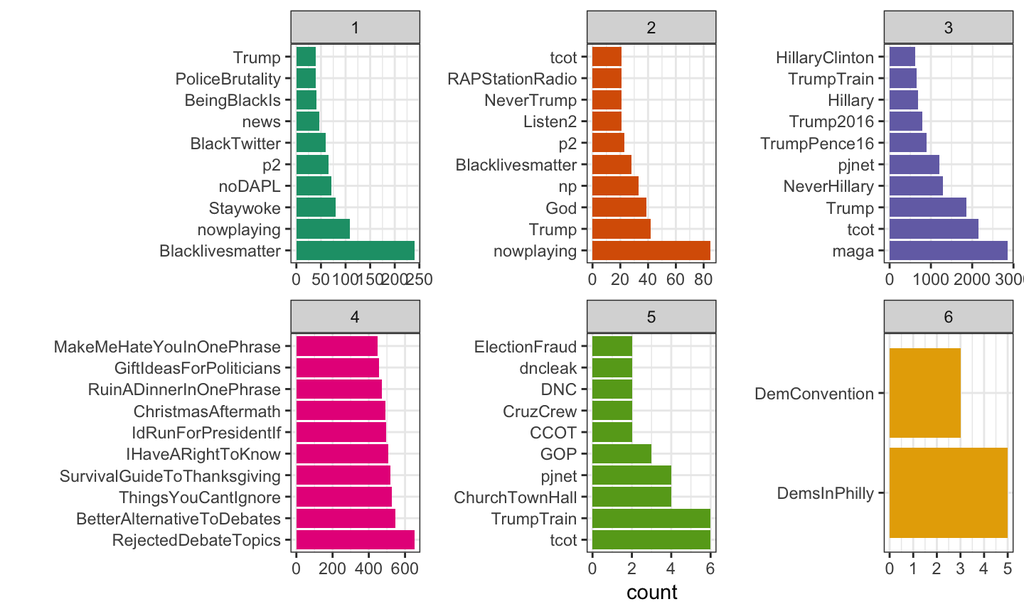

## Explore the usage of hashtags

## Create a bipartite graph

| user_key | hashtags |
| --- | --- |
| ryanmaxwell_1 | IslamKills |
| queenofthewo | ChristmasAftermath |
| hiimkhloe | Blacklivesmatter |
| jasper_fly | MyFarewellWordsWouldBe |
| giselleevns | My2017BiggestHope |
| pamela_moore13 | Obama |

## Aggregate Bipartite

| user_key | hashtags | weight | type |
| --- | --- | --- | --- |
| @newspeakdaily | #politics | 735 | used_hashtag |
| @ameliebaldwin | #maga | 605 | used_hashtag |
| @kansasdailynews | #news | 573 | used_hashtag |
| @onlinecleveland | #politics | 501 | used_hashtag |
| @washingtonline | #politics | 393 | used_hashtag |
| @todaybostonma | #politics | 382 | used_hashtag |

## Create Graph

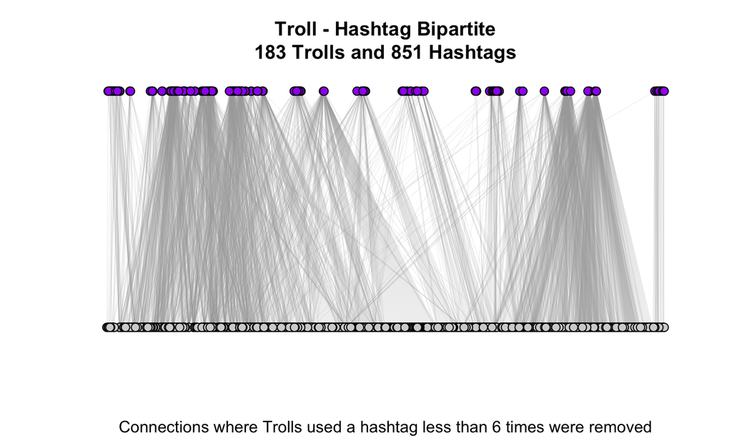

## Indirect Hashtag Connections

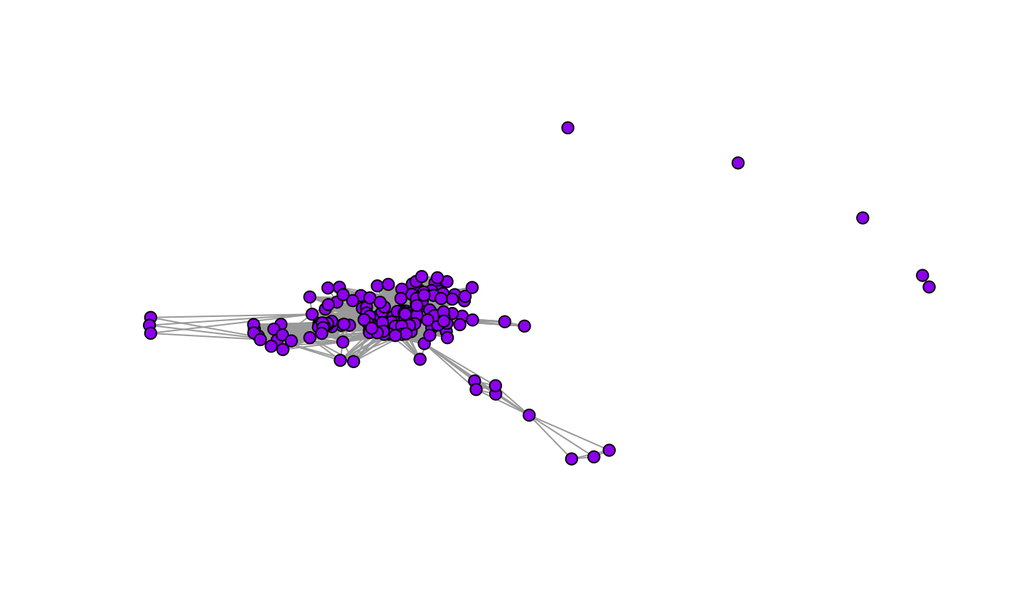

## Indirect User Connections

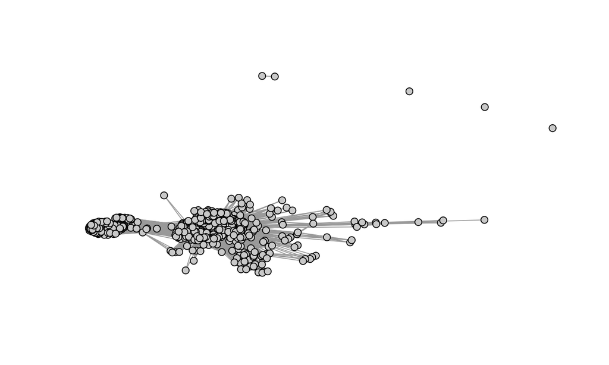

## Examine largest component

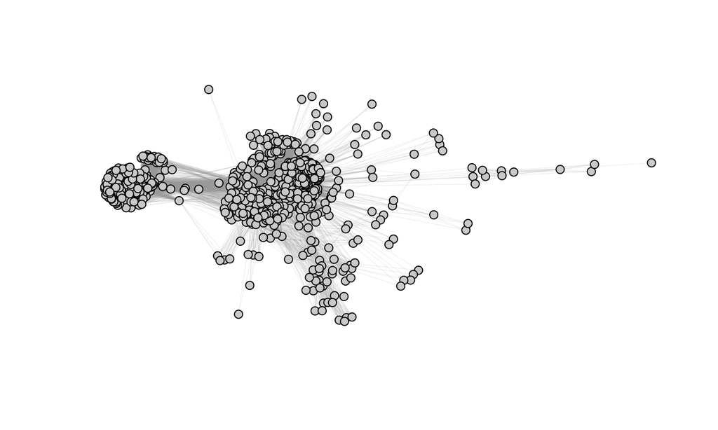

## Community Detection and PageRank

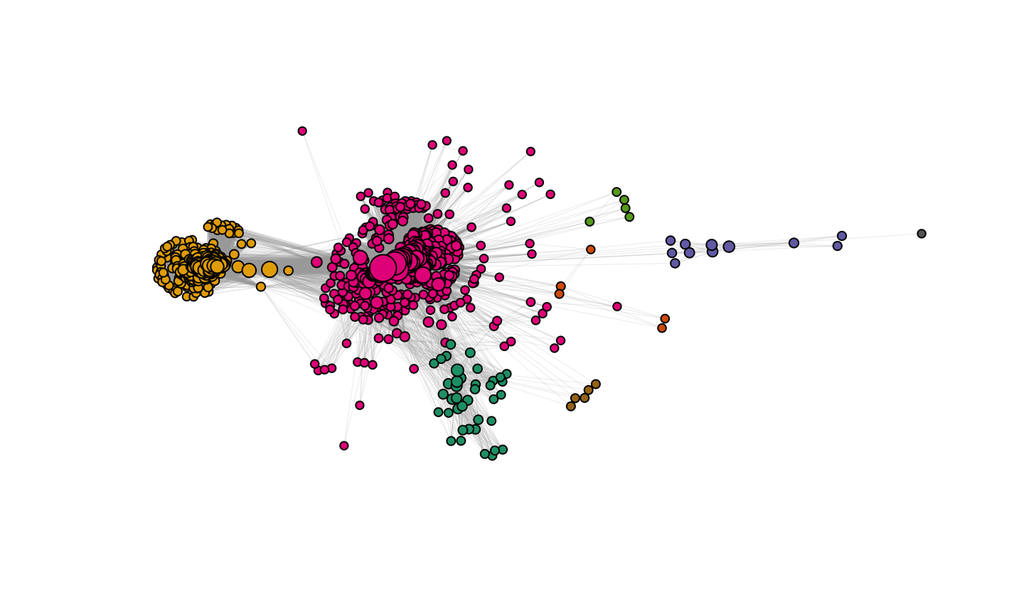

## Sample of Hashtags

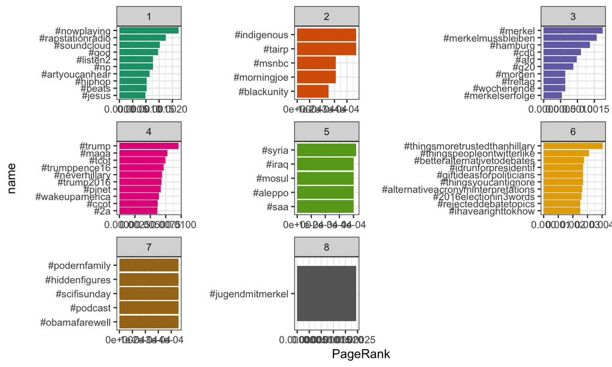

## How do these groups interact?

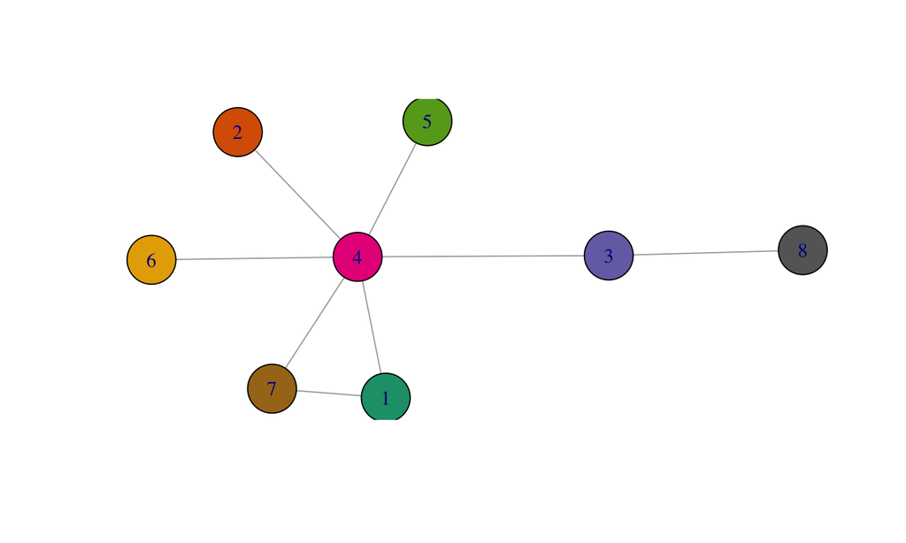

## Community Hashtags

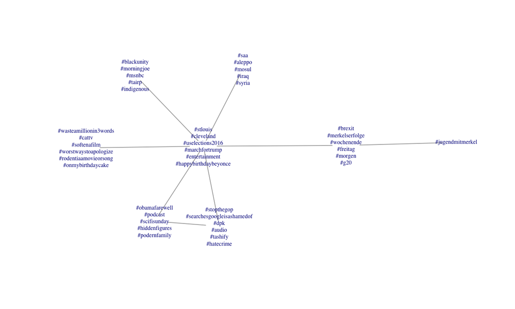

## Hashtags Connecting Communities

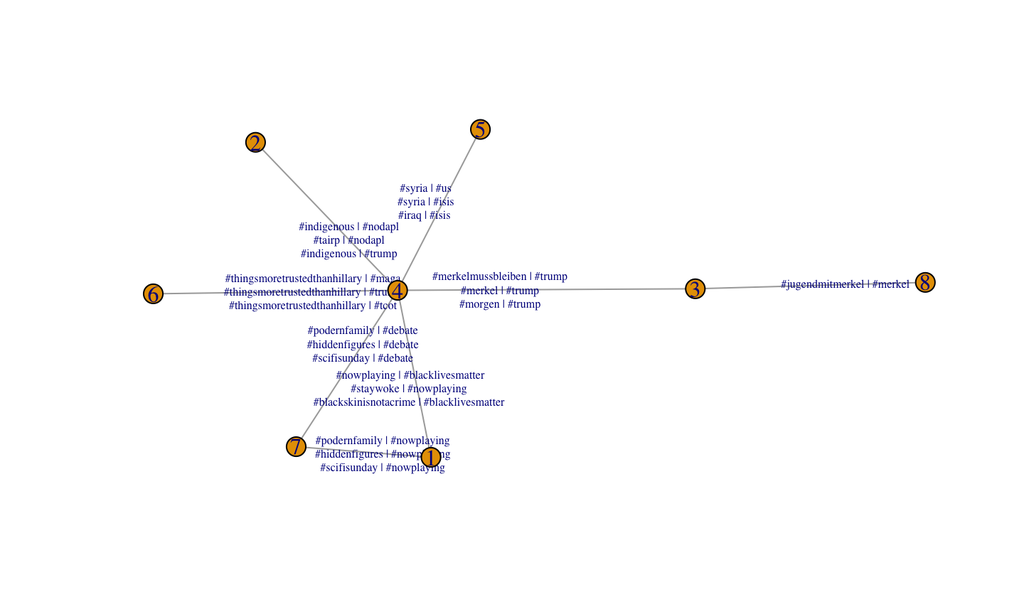

## Using Simple Topic Models